# State space model autotrophic rivers

Alice Carter

10/11/2021

### Questions:

1. What are the important drivers of metabolism in rivers if we consider the element of time in our models?
2. Are the drivers of GPP in autotrophic rivers the same as in heterotrophic rivers?

To begin, I will use this as an opportunity to work through the mechanics of a state space model in stan by building a simple autoregressive model of GPP incorporating light as a control.

### Data

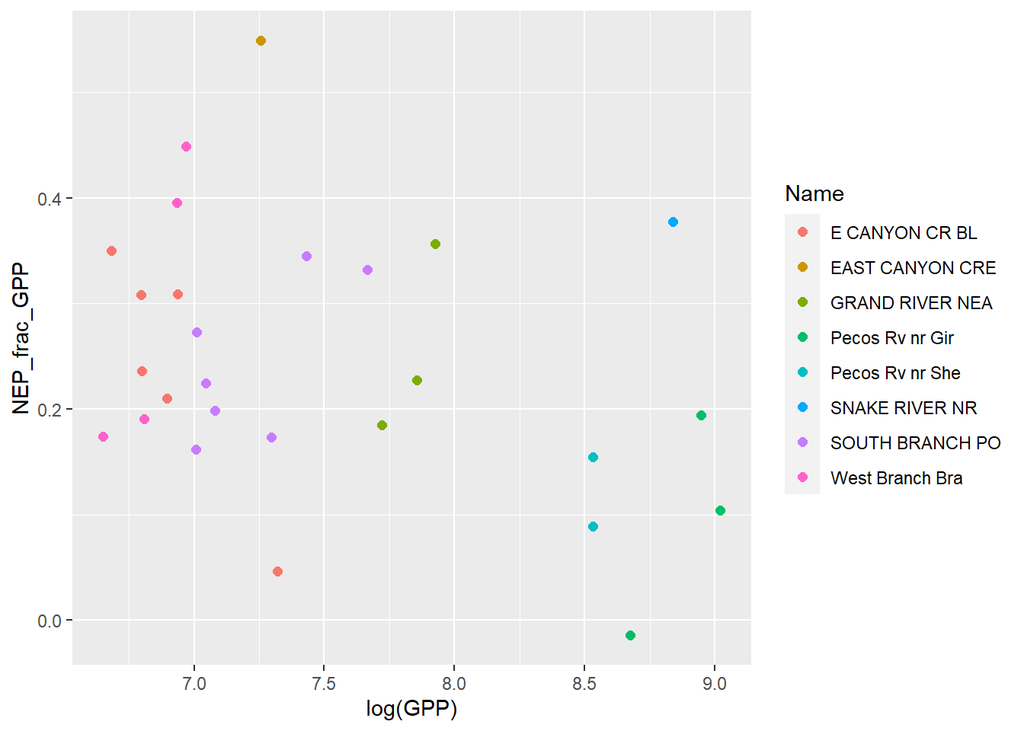

```r
auto <- read_csv('C:/Users/Alice Carter/git/autotrophic_rivers/data/selected_autotrophic_rivers_daily.csv')%>%
  mutate(Name = substr(Name, 1, 15))

annual <- auto %>%
  group_by(sitecode, Name, year) %>%
  summarize(GPP = sum(GPP, na.rm = T),
            ER = sum(ER, na.rm = T),
            par_av = sum(!is.na(light_PAR))/365,
            NEP_frac_GPP = (GPP+ER)/GPP)

ggplot(annual, aes(log(GPP), NEP_frac_GPP, col = Name)) +
  geom_point(size = 2)
```

I have decided to start with three of them:

1. Pecos river near Girvin, TX (high GPP)
2. East Canyon Creek below I-80, UT (high NEP/GPP)
3. Grand River near Eastmanfille, MI (medium high GPP, medium high NEP/GPP)

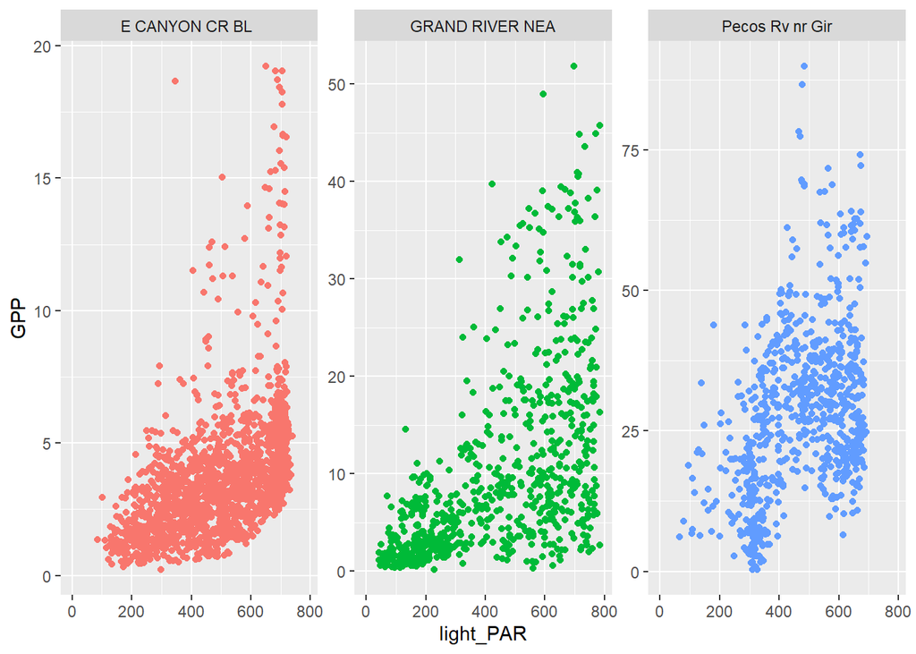

```r
# select the three sites of interest:
p_code <- 'nwis_08446500'   # pecos river near Girvin
ec_code <- 'nwis_10133650'  # east canyon creek near I-80
gr_code <- 'nwis_04119400'  # grand river enar eastmanville

pecos <- auto %>%
  filter(sitecode == p_code)

east <- auto %>%
  filter(sitecode == ec_code)

grand <- auto %>%
  filter(sitecode == gr_code)

bind_rows(pecos, east, grand) %>%
  ggplot(aes(light_PAR, GPP, color = Name)) +
  geom_point() +
  facet_wrap(~Name, scales = 'free_y')+
  theme(legend.position = 'none')
```

Unsurprisingly, it looks like at each of these streams, GPP is correlated with light.

### Model

First, we need to deal with missing data. I am going to save this piece for later, after talking to Matt and after getting an initial model working. For now I am just doing a linear interpolation of any gaps.

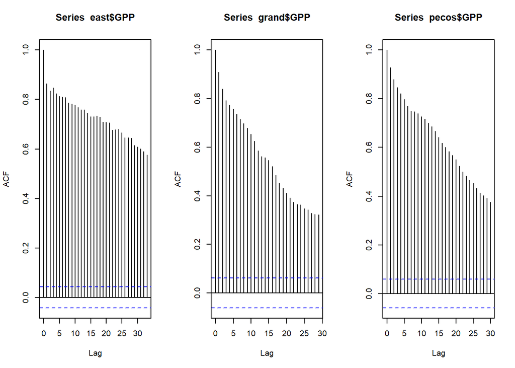

```r
east <- east %>%
  arrange(Date) %>%
  select(sitecode, date = Date, GPP, light_PAR) %>%
  mutate(across(c('GPP', 'light_PAR'),
                ~ zoo::na.approx(., na.rm = F))) %>%
  filter(!is.na(GPP), !is.na(light_PAR))

grand <- grand %>%
  arrange(Date) %>%
   select(sitecode, date = Date, GPP, light_PAR) %>%
  mutate(across(c('GPP', 'light_PAR'),
                ~ zoo::na.approx(., na.rm = F))) %>%
  filter(!is.na(GPP), !is.na(light_PAR))

pecos <- pecos %>%
  arrange(Date) %>%
  select(sitecode, date = Date, GPP, light_PAR) %>%
  mutate(across(c('GPP', 'light_PAR'),
                ~ zoo::na.approx(., na.rm = F))) %>%
  filter(!is.na(GPP), !is.na(light_PAR))

# Check to see the autocorrelation pattern
par(mfrow = c(1,3))
acf(east$GPP)
acf(grand$GPP)
acf(pecos$GPP)
```

All of them are very autocorrelated, an autoregressive model probably makes sense.

#### Model equations

$$x_t = \phi * x_{t-1} + \beta_0 + \beta_1 * PAR_t + \epsilon_t$$
$$\epsilon_t \sim normal(0, \sigma_t)$$
$$y_t \sim Normal(x_t, \omega)$$

where $y_t$ is the observed value of the underlying process, $x_t$, $\omega$ is the observation error and $\sigma$ is the process error.

#### Priors:

$\phi \sim Uniform(0,1)$

$\beta_0 \sim Normal(0,10)$

$\beta_1 \sim Log Normal(0,1)$

$\sigma \sim Exponential(1)$

$\omega \sim Exponential(1)$

Below is the code for the stan model.

```r
write("// Stan simple autoregressive model

data {
 int <lower = 0> N; // Sample size
 vector[N] GPP_obs; // observed values, y
 vector[N] light_PAR; // driver
 real GPP_obs_1;
}

parameters {

 real < lower = 0, upper = 1> phi;
 real beta0; // Intercept
 real < lower = 0 > beta1; // constrained to positive values
 real < lower = 0 > sigma;
 real < lower = 0 > omega;
 vector[N] GPP_mod;
}

model {

 GPP_mod[1] ~ normal(GPP_obs_1, 1);
 for(i in 2:N){
  GPP_mod[i] ~ normal(phi * GPP_mod[i-1] + beta0 + beta1 * light_PAR[i], sigma);
 }
 GPP_obs ~ normal(GPP_mod, omega);

 //priors
 phi ~ uniform(0,1);
 beta0 ~ normal(0,10);
 beta1 ~ lognormal(0,1);
 sigma ~ exponential(1);
 omega ~ exponential(1);

}

generated quantities {
} ",

"src/state_space/ar1_model.stan")

stanc('src/state_space/ar1_model.stan')
ar1_mod <- 'src/state_space/ar1_model.stan'
```

```r
stan_dat <- list(N = nrow(east), GPP_obs = east$GPP, GPP_obs_1 = east$GPP[1],
                 light_PAR = east$light_PAR)
fit_east <- stan(file = ar1_mod, data = stan_dat, warmup = 500, iter = 10000,
            chains = 4, cores = 2, thin = 1)
saveRDS(fit_east, 'data/model_fits/east_ar1.rds')

stan_dat <- list(N = nrow(grand), GPP_obs = grand$GPP, GPP_obs_1 = grand$GPP[1],
                 light_PAR = grand$light_PAR)
fit_grand <- stan(file = ar1_mod, data = stan_dat, warmup = 500, iter = 10000,
            chains = 4, cores = 2, thin = 1)
saveRDS(fit_grand, 'data/model_fits/grand_ar1.rds')

stan_dat <- list(N = nrow(pecos), GPP_obs = pecos$GPP, GPP_obs_1 = pecos$GPP[1],
                 light_PAR = pecos$light_PAR)
fit_pecos <- stan(file = ar1_mod, data = stan_dat, warmup = 500, iter = 10000,
            chains = 4, cores = 2, thin = 1)
saveRDS(fit_pecos, 'data/model_fits/pecos_ar1.rds')
```

### Model Fit

Below are results of the model fit for the Grand River. In all three cases, the model is struggling to resolve observation error ($\omega$), with the worst example shown below.

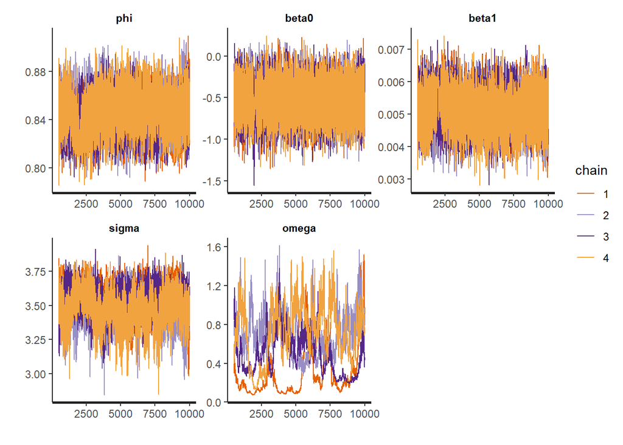

```r
fit <- readRDS('C:/Users/Alice Carter/git/autotrophic_rivers/data/model_fits/grand_ar1.rds')


traceplot(fit, c('phi', 'beta0', 'beta1', 'sigma', 'omega'))
```

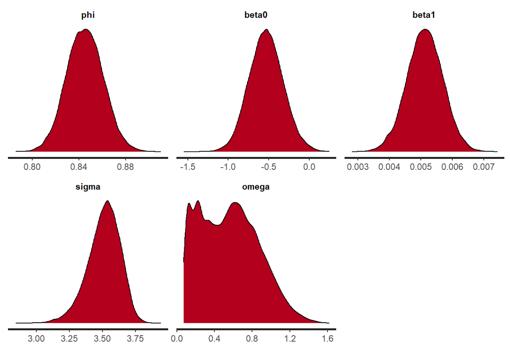

```r
stan_dens(fit,  c('phi', 'beta0', 'beta1', 'sigma', 'omega'))
```

Model predicted GPP:

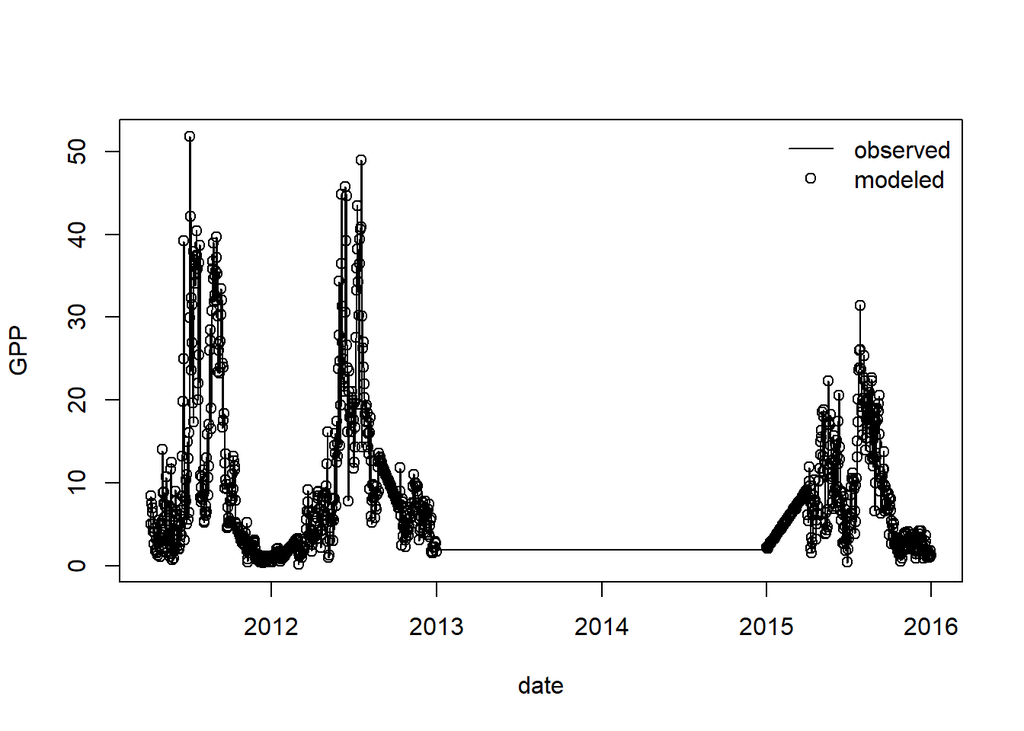

```r
posterior <- extract(fit)
plot(grand$date, grand$GPP, type = 'l',
     xlab = 'date', ylab = 'GPP')
points(grand$date, posterior$GPP_mod[1,])
legend('topright', c('observed', 'modeled'),
       lty = c(1,0), pch = c(NA,1), bty = 'n')
```

### Next Steps

1. Discuss model:
- Is this structure correct for an autoregressive model? I’m unsure about the way I am defining the initial state, GPP[1]
- Should I be normalizing all of the variables?
- Are these priors reasonable or are there better ones I should be using?
- What should I be thinking about in looking at the model fit?
2. Compare dynamics across streams:
- How does light dependence vary across autotrophic streams?
- Does light dependence differ systematically in autotrophic vs heterotrophic streams?
- Is the model fit different in autotrophic vs heterotrophic streams different? ie, is there a different degree of autoregressive correlation of GPP?
3. Add other explanatory variables:
- Add a disturbance term for discharge, maybe like an error in a moving average model?
- Water temperature? How do dynamics differ in streams where light and temperature covary vs streams where they don’t?
4. Pool parameters across streams